# Filtering SNPs in a vcf file

This is a completely unfiltered vcf file (SNPs were called in populations with no filters). We will start by visualizing the depth of sequencing and genotype quality.

```r
## When there is no filters set, the function will show visuals
hard_filter(vcf)
```

```
## no depth cutoff provided, exploratory visualization will be generated.
```

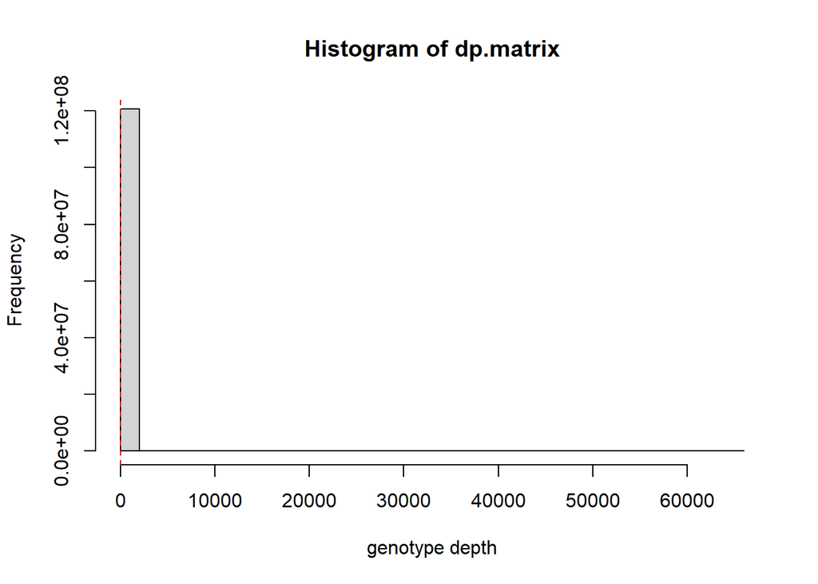

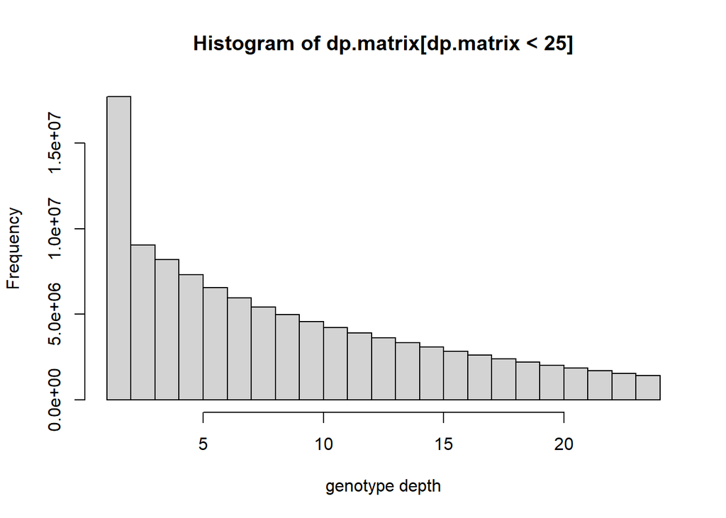

```
## no genotype quality cutoff provided, exploratory visualization will be generated.
```

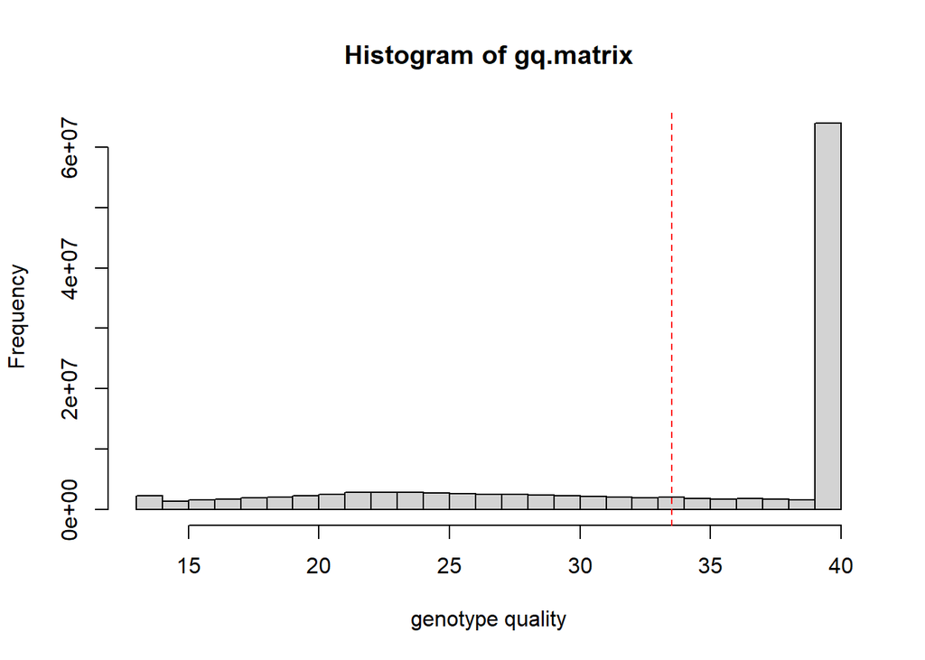

```
## ***** Object of Class vcfR *****
## 46 samples
## 1289 CHROMs
## 4,606,447 variants
## Object size: 4800.2 Mb
## 43.08 percent missing data
## *****        *****         *****
```

From the histograms we can see that setting depth to 5 and quality to 20 is reasonable for this vcf.

```r
vcf_filtered <- hard_filter(vcf, depth = 5, gq = 20)
```

```
## 28.98% of genotypes fall below a read depth of 5 and were converted to NA
```

```
## 0.8% of genotypes fall below a genotype quality of 20 and were converted to NA
```

```r
vcf_filtered
```

```
## ***** Object of Class vcfR *****
## 46 samples
## 1289 CHROMs
## 4,606,447 variants
## Object size: 4663.4 Mb
## 59.89 percent missing data
## *****        *****         *****
```

**Interpretation**

#### Step 2: Allele balance

This represents the ratio of reads showing the reference allele to all reads. Expected ratio is 0.5, thus if there are large devisions this may indicate false heterozygotes due to coverage. This essentially filters for min and max heterozygosity.

```r
vcf_filtered_AB <- filter_allele_balance(vcf_filtered, min.ratio = 0.25, max.ratio = 0.75)
```

```
## 20.85% of het genotypes (2.2% of all genotypes) fall outside of 0.25 - 0.75 allele balance ratio and were converted to NA
```

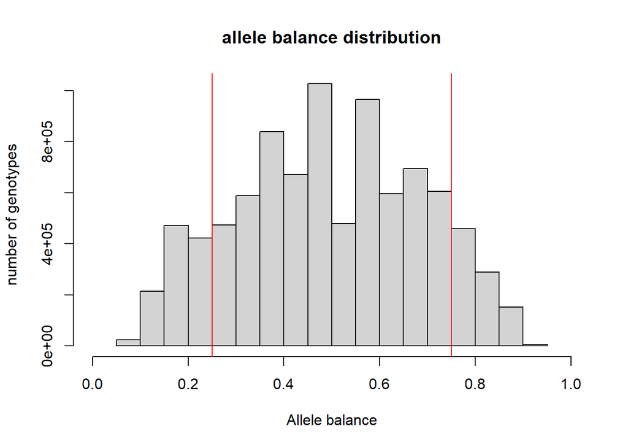

#### Step 3: Maximum depth per SNP

Removing SNPs with outlier depth values - will most likely remove SNPs that are spuriously mapped or paralogous loci.

```r
## Visualize the max depth without setting any filters
max_depth(vcf_filtered)
```

```
## cutoff is not specified, exploratory visualization will be generated.
```

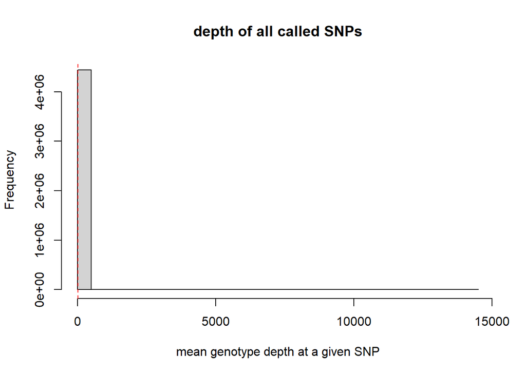

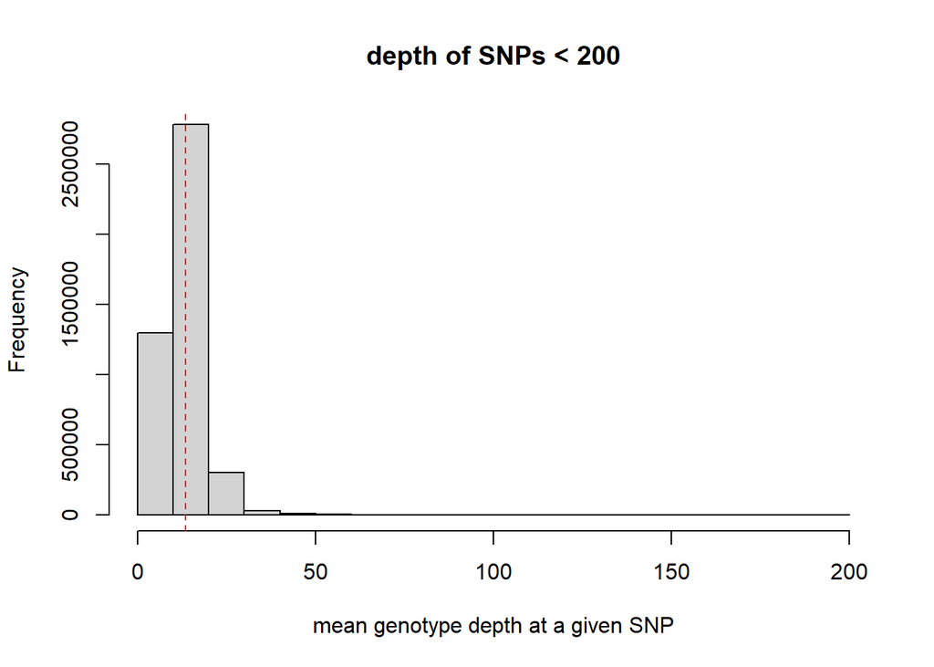

```
## dashed line indicates a mean depth across all SNPs of 13.6
```

We will set this to 22 to cut off the majority of the tail in the histogram (mean depth is 13.6)

```r
vcf_filtered <- max_depth(vcf_filtered_AB, maxdepth = 22)
```

```
## maxdepth cutoff is specified, filtered vcfR object will be returned
```

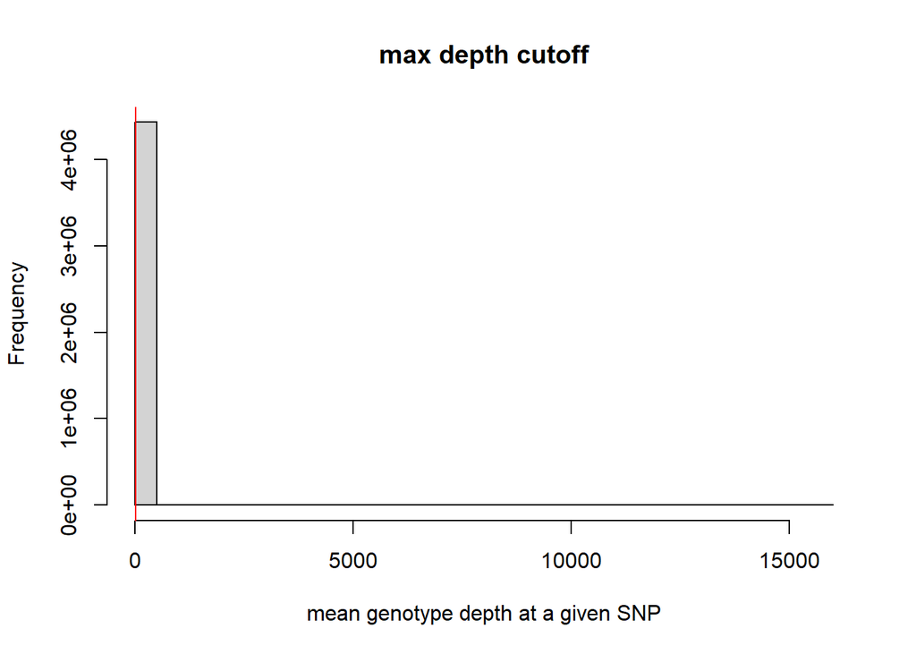

```
## 4.19% of SNPs were above a mean depth of 22 and were removed from the vcf
```

#### Step 4: Minor allele count

We will then set MAC to 3 for the downstream analyses.

```r
vcf_mac3 <- min_mac(vcf_filtered, min.mac = 3)
```

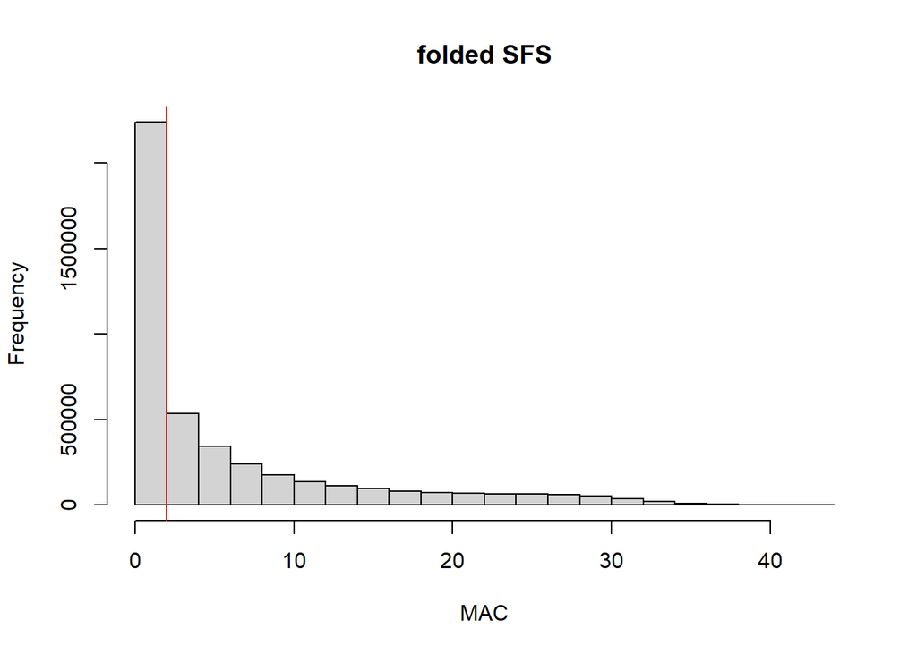

```
## 50.76% of SNPs fell below a minor allele count of 3 and were removed from the VCF
```

```r
vcf_mac3
```

```
## ***** Object of Class vcfR *****
## 46 samples
## 989 CHROMs
## 2,171,753 variants
## Object size: 2684 Mb
## 48.96 percent missing data
## *****        *****         *****
```

```r
#vcfR::write.vcf(vcf_mac3, "./filtered_vcf/HO_0.5_mac3_AB0.25-0.75.vcf.gz")
#vcf_mac3 <- read.vcfR("./filtered_vcf/HO_0.5_mac3_AB0.2-0.8.vcf.gz")
```

#### Step 5: Missing data

We will start by looking at the missing data per SNP and missing data per sample

```r
missing_by_snp(vcf_mac3)
```

```
## cutoff is not specified, exploratory visualizations will be generated
```

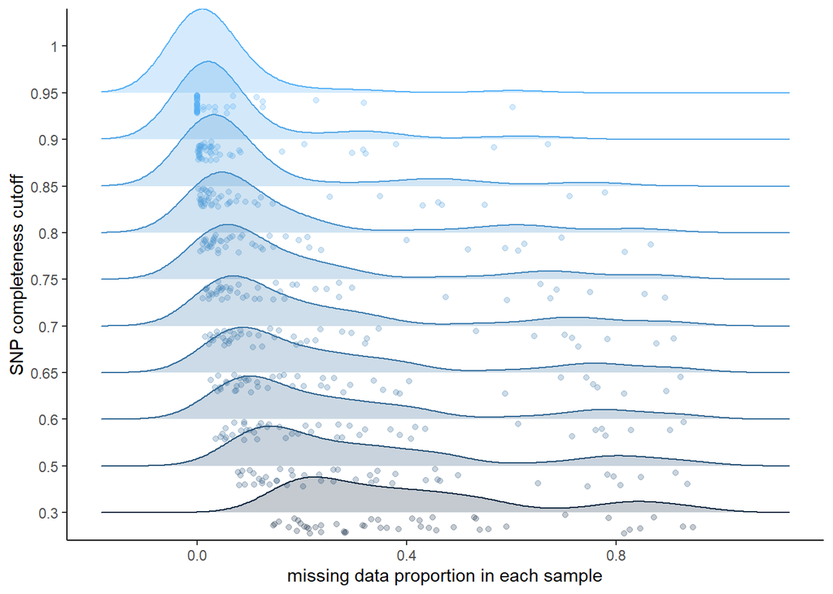

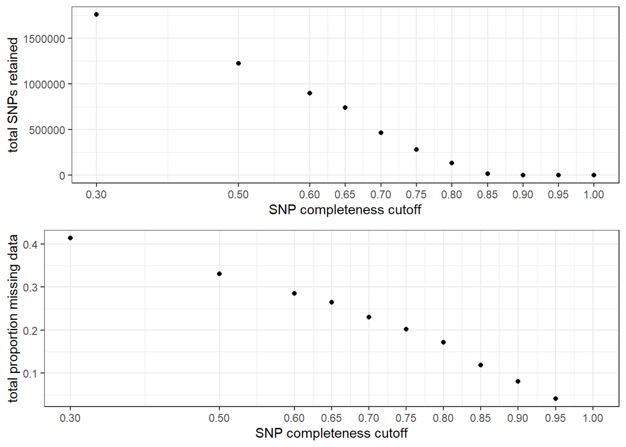

```
##    filt missingness snps.retained
## 1  0.30  0.41352332       1759234
## 2  0.50  0.33097588       1225952
## 3  0.60  0.28530079        896361
## 4  0.65  0.26504202        738566
## 5  0.70  0.22993310        467120
## 6  0.75  0.20236304        282203
## 7  0.80  0.17156683        131331
## 8  0.85  0.11902899         18061
## 9  0.90  0.08098257          2016
## 10 0.95  0.04076087            88
## 11 1.00         NaN             0
```

```r
missing_by_sample(vcf_mac3)
```

```
## No popmap provided
```

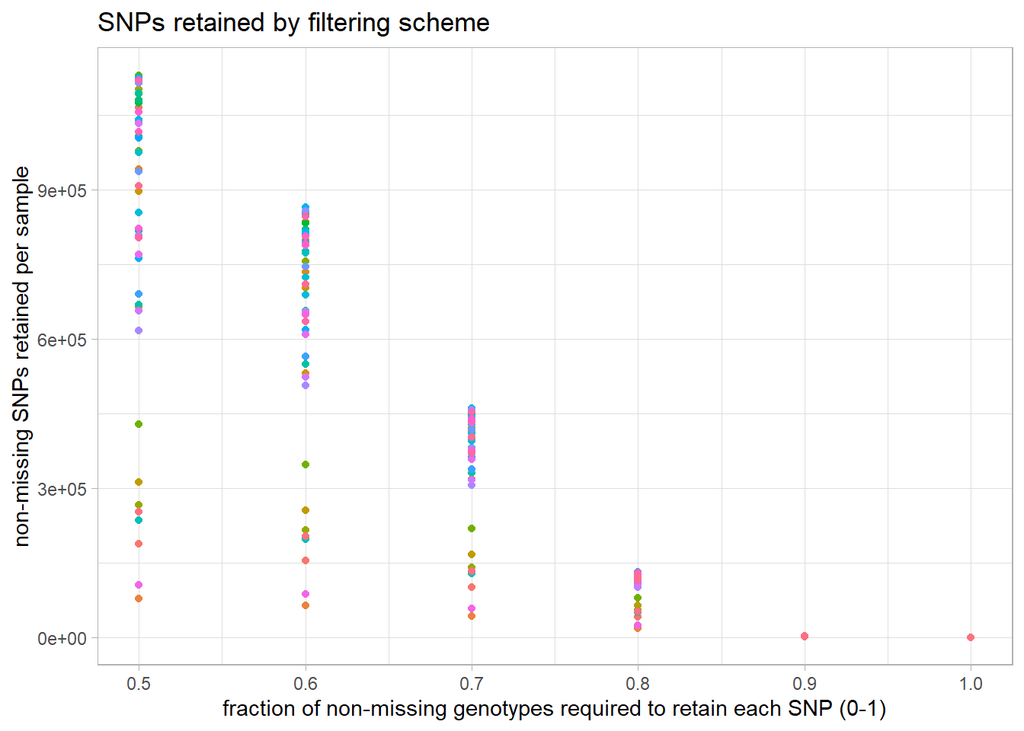

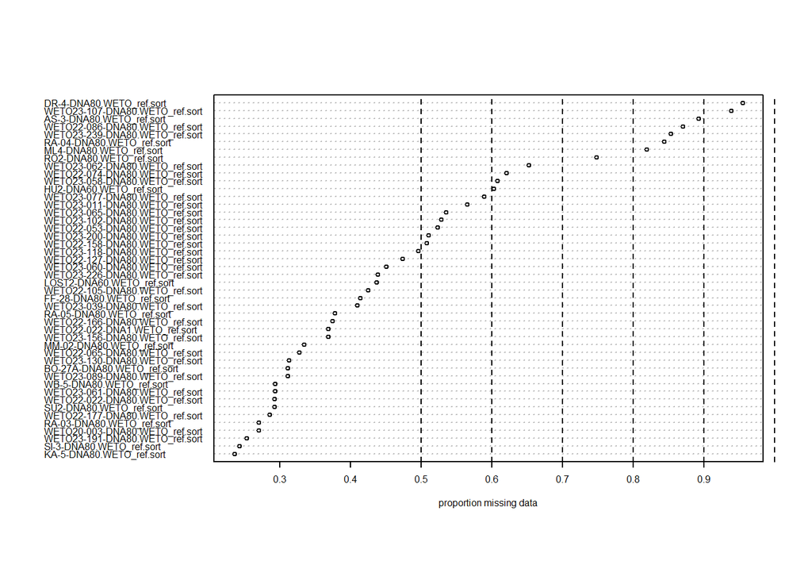

```
##                              indiv filt snps.retained
## 1         AS-3-DNA80.WETO_ref.sort  0.5        187285
## 2       BO-27A-DNA80.WETO_ref.sort  0.5       1064951
## 3         DR-4-DNA80.WETO_ref.sort  0.5         77791
## 4        FF-28-DNA80.WETO_ref.sort  0.5        941010
## 5          HU2-DNA60.WETO_ref.sort  0.5        663803
## 6         KA-5-DNA80.WETO_ref.sort  0.5       1127521
## 7        LOST2-DNA60.WETO_ref.sort  0.5        896864
## 8          ML4-DNA80.WETO_ref.sort  0.5        311780
## 9        MM-02-DNA80.WETO_ref.sort  0.5       1038667
## 10       RA-03-DNA80.WETO_ref.sort  0.5       1102361
## 11       RA-04-DNA80.WETO_ref.sort  0.5        265891
## 12       RA-05-DNA80.WETO_ref.sort  0.5        978331
## 13         RO2-DNA80.WETO_ref.sort  0.5        428301
## 14        SI-3-DNA80.WETO_ref.sort  0.5       1130063
```

[output cut: 262 more lines]

### Dataset with less missing data

Due to the two individuals with high amount of missing data (>90%) we will start by removing these two individuals:

```r
vcf_mac3_imiss90 <- missing_by_sample(vcfR=vcf_mac3, cutoff=0.9)
```

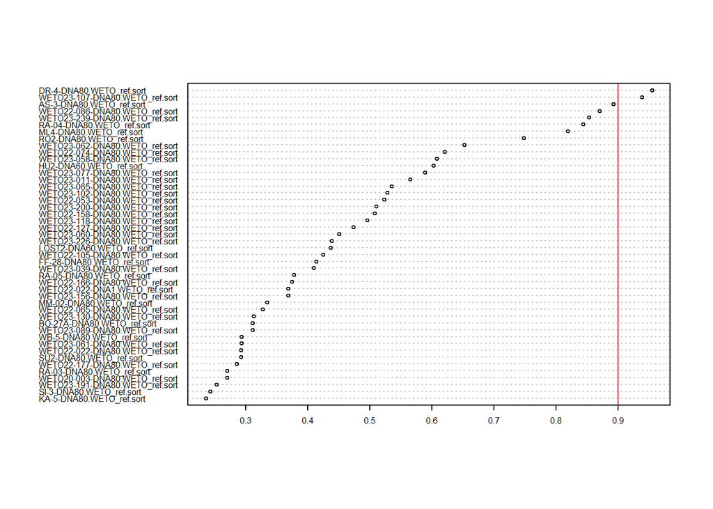

```
## 2 samples are above a 0.9 missing data cutoff, and were removed from VCF
```

Check missingness by SNP:

```r
missing_by_snp(vcf_mac3_imiss90)
```

```
## cutoff is not specified, exploratory visualizations will be generated
```

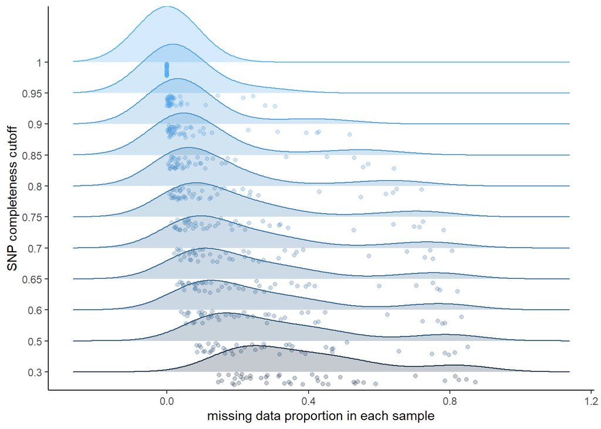

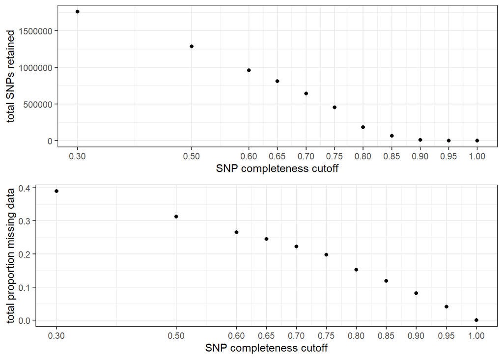

```
##    filt missingness snps.retained
## 1  0.30  0.38933977       1757132
## 2  0.50  0.31284739       1284176
## 3  0.60  0.26532532        960834
## 4  0.65  0.24510413        810758
## 5  0.70  0.22281704        640872
## 6  0.75  0.19751289        453132
## 7  0.80  0.15299197        185893
## 8  0.85  0.11892819         66625
## 9  0.90  0.08123710         13173
## 10 0.95  0.04103535          1008
## 11 1.00  0.00000000            18
```

We will set the missing data per SNP to 85%:

```r
vcf_mac3_imiss90_SNP85 <- missing_by_snp(vcf_mac3_imiss90, 0.85)
```

```
## cutoff is specified, filtered vcfR object will be returned
```

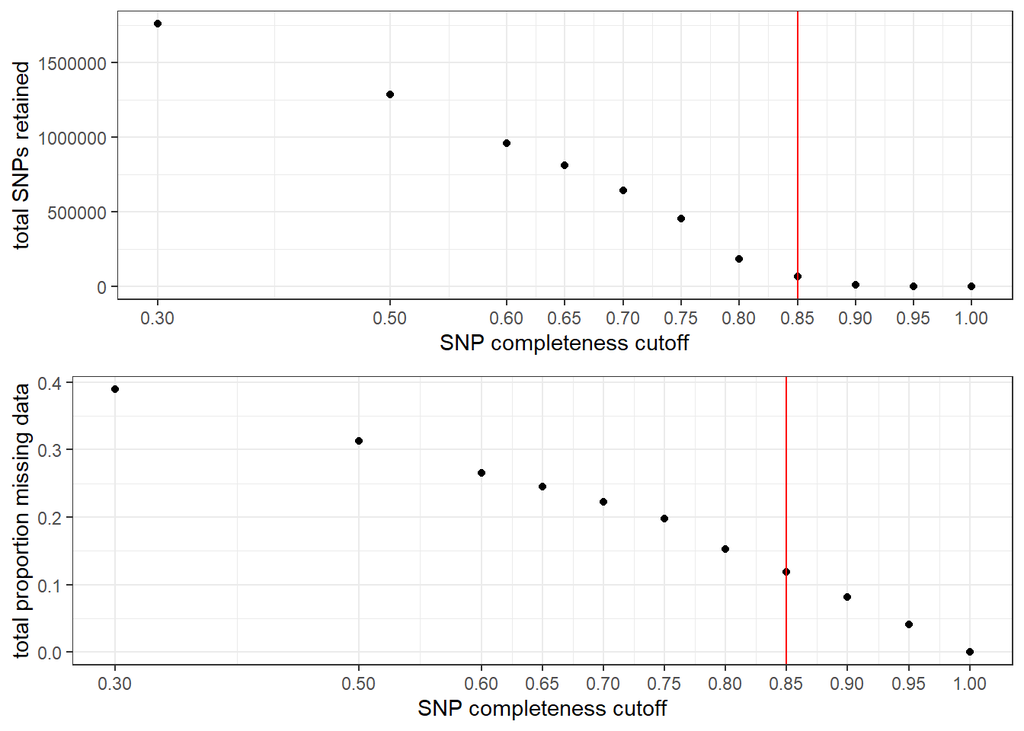

```
## 96.93% of SNPs fell below a completeness cutoff of 0.85 and were removed from the VCF
```

Now look at the missing data per sample:

```r
missing_by_sample(vcf_mac3_imiss90_SNP85)
```

```
## No popmap provided
```

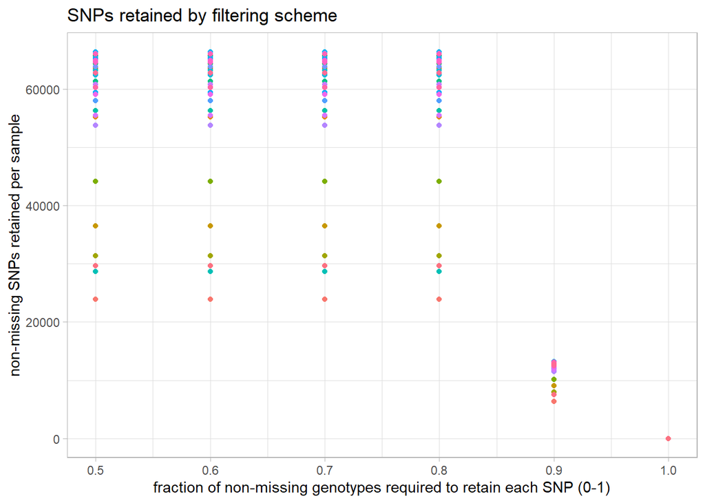

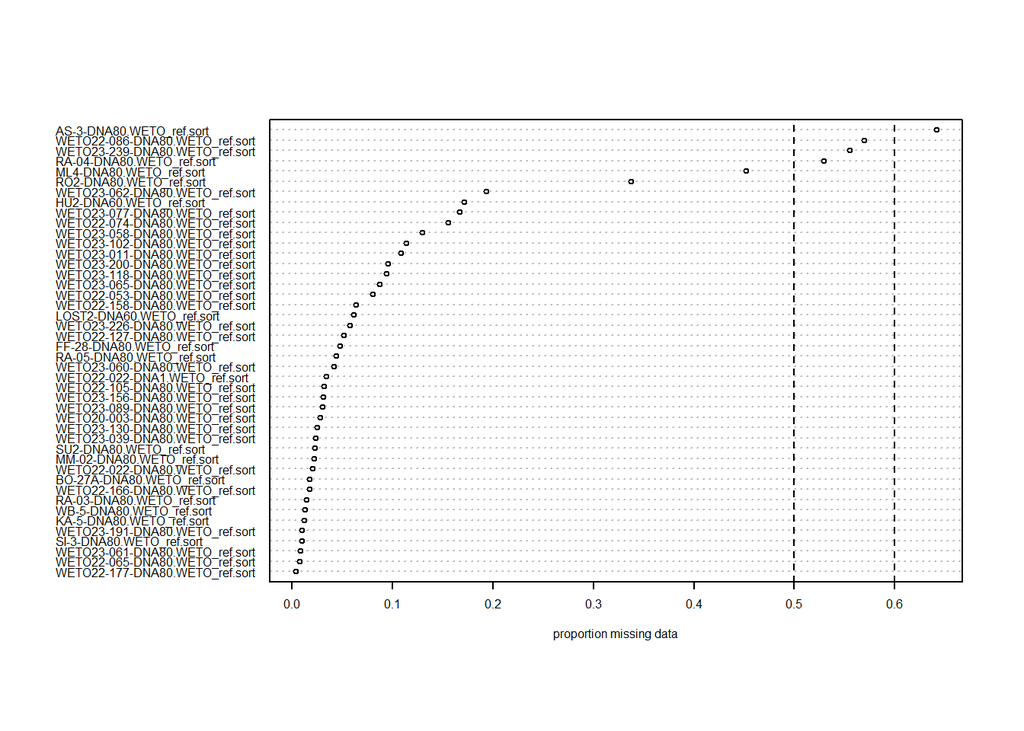

```
##                              indiv filt snps.retained
## 1         AS-3-DNA80.WETO_ref.sort  0.5         23876
## 2       BO-27A-DNA80.WETO_ref.sort  0.5         65446
## 3        FF-28-DNA80.WETO_ref.sort  0.5         63447
## 4          HU2-DNA60.WETO_ref.sort  0.5         55190
## 5         KA-5-DNA80.WETO_ref.sort  0.5         65823
## 6        LOST2-DNA60.WETO_ref.sort  0.5         62545
## 7          ML4-DNA80.WETO_ref.sort  0.5         36523
## 8        MM-02-DNA80.WETO_ref.sort  0.5         65168
## 9        RA-03-DNA80.WETO_ref.sort  0.5         65663
## 10       RA-04-DNA80.WETO_ref.sort  0.5         31349
## 11       RA-05-DNA80.WETO_ref.sort  0.5         63714
## 12         RO2-DNA80.WETO_ref.sort  0.5         44140
## 13        SI-3-DNA80.WETO_ref.sort  0.5         65983
## 14         SU2-DNA80.WETO_ref.sort  0.5         65085
```

[output cut: 250 more lines]

```r
vcf_mac3_imiss50_SNP85 <- missing_by_sample(vcfR=vcf_mac3_imiss90_SNP85, cutoff = 0.5)
```

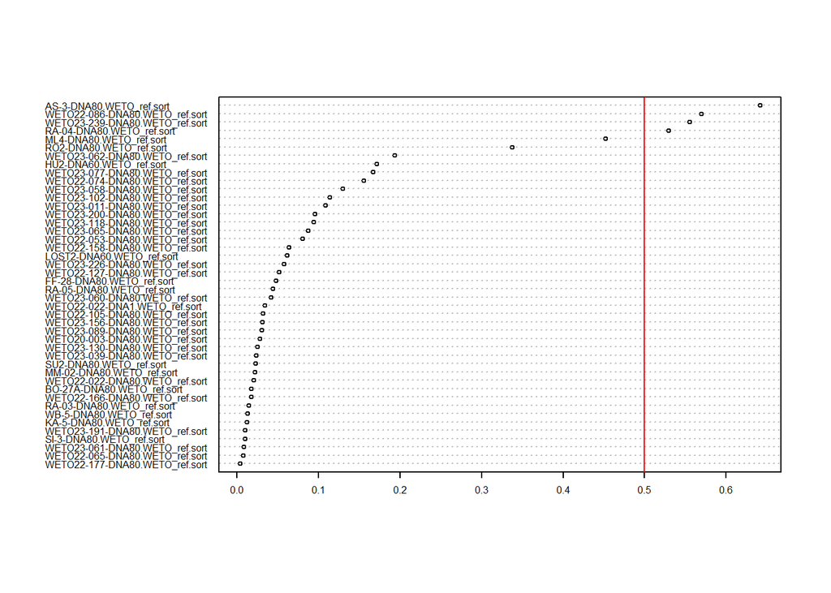

```
## 4 samples are above a 0.5 missing data cutoff, and were removed from VCF
```

Check missingness by SNP:

```r
missing_by_snp(vcf_mac3_imiss50_SNP85)
```

```
## cutoff is not specified, exploratory visualizations will be generated
```

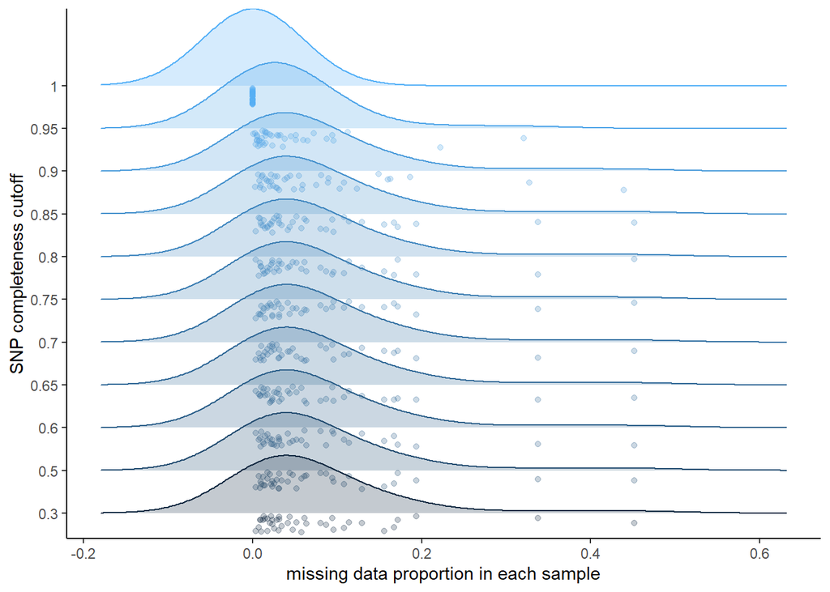

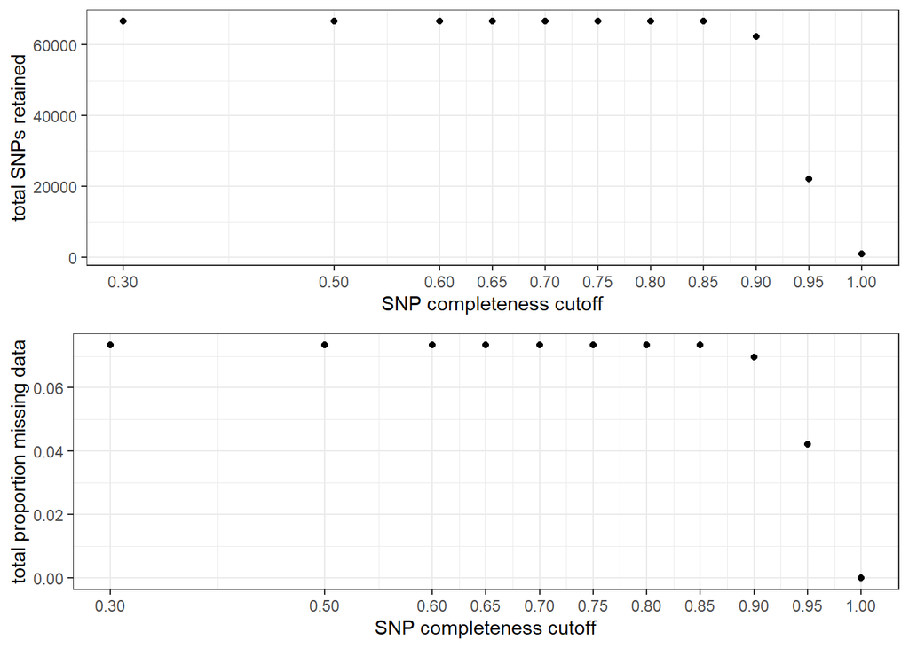

```
##    filt missingness snps.retained
## 1  0.30  0.07344240         66625
## 2  0.50  0.07344240         66625
## 3  0.60  0.07344240         66625
## 4  0.65  0.07344240         66625
## 5  0.70  0.07344240         66625
## 6  0.75  0.07344240         66625
## 7  0.80  0.07344240         66625
## 8  0.85  0.07344240         66625
## 9  0.90  0.06973684         62301
## 10 0.95  0.04225405         22118
## 11 1.00  0.00000000           882
```

Setting missing by SNP to 0.95 (to try to reduce the amount of missingness per individual - i.e. to keep more individuals):

```r
vcf_mac3_imiss50_SNP95 <- missing_by_snp(vcf_mac3_imiss50_SNP85, 0.95)
```

```
## cutoff is specified, filtered vcfR object will be returned
```

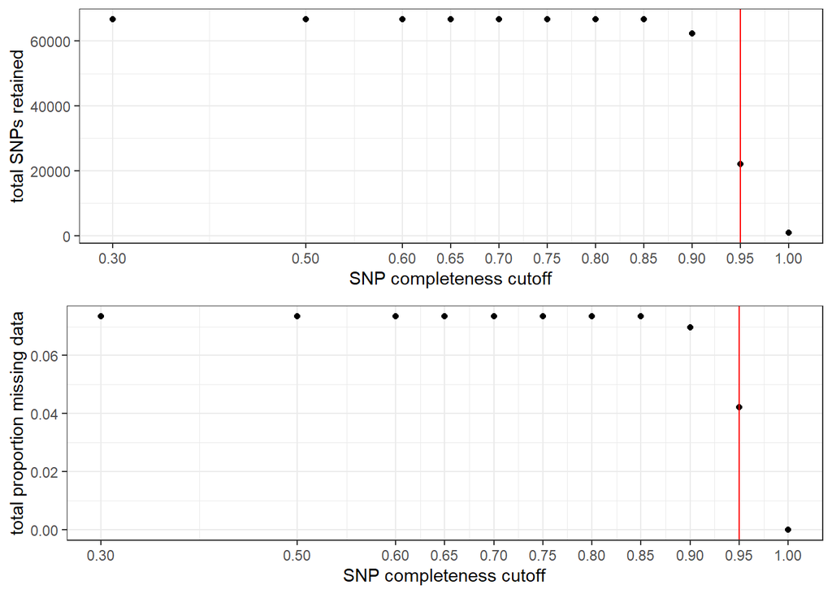

```
## 66.8% of SNPs fell below a completeness cutoff of 0.95 and were removed from the VCF
```

Now I will recheck the missing data per sample:

```r
missing_by_sample(vcf_mac3_imiss50_SNP95)
```

```
## No popmap provided
```

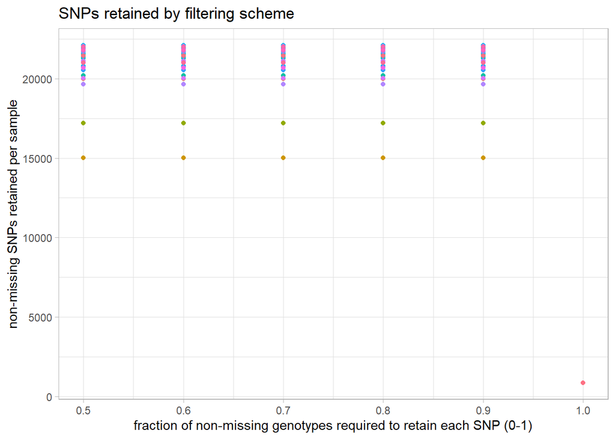

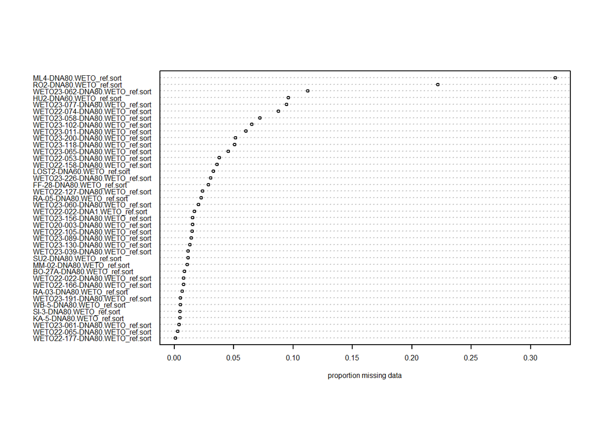

```
##                              indiv filt snps.retained
## 1       BO-27A-DNA80.WETO_ref.sort  0.5         21933
## 2        FF-28-DNA80.WETO_ref.sort  0.5         21481
## 3          HU2-DNA60.WETO_ref.sort  0.5         19996
## 4         KA-5-DNA80.WETO_ref.sort  0.5         22015
## 5        LOST2-DNA60.WETO_ref.sort  0.5         21391
## 6          ML4-DNA80.WETO_ref.sort  0.5         15024
## 7        MM-02-DNA80.WETO_ref.sort  0.5         21879
## 8        RA-03-DNA80.WETO_ref.sort  0.5         21976
## 9        RA-05-DNA80.WETO_ref.sort  0.5         21623
## 10         RO2-DNA80.WETO_ref.sort  0.5         17214
## 11        SI-3-DNA80.WETO_ref.sort  0.5         22015
## 12         SU2-DNA80.WETO_ref.sort  0.5         21867
## 13        WB-5-DNA80.WETO_ref.sort  0.5         22006
## 14  WETO20-003-DNA80.WETO_ref.sort  0.5         21778
```

[output cut: 226 more lines]

```r
vcf_mac3_imiss33_SNP95 <- missing_by_sample(vcfR=vcf_mac3_imiss50_SNP95, cutoff=0.33)
```

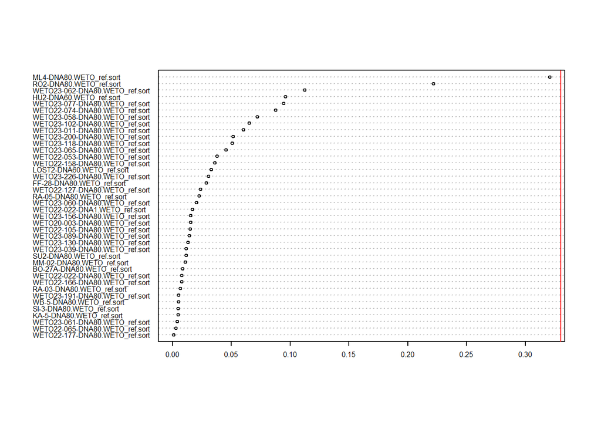

```
## 0 samples are above a 0.33 missing data cutoff, and were removed from VCF
```

Double check the depth and genotype quality across SNPs and samples:

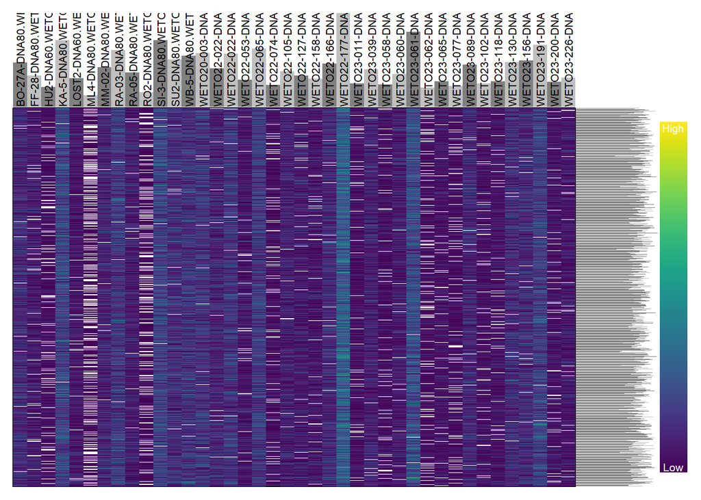

```r
## Depth per snp and per sample
dp <- extract.gt(vcf_mac3_imiss33_SNP95, element = "DP", as.numeric = TRUE)

heatmap.bp(dp, rlabels = FALSE)
```

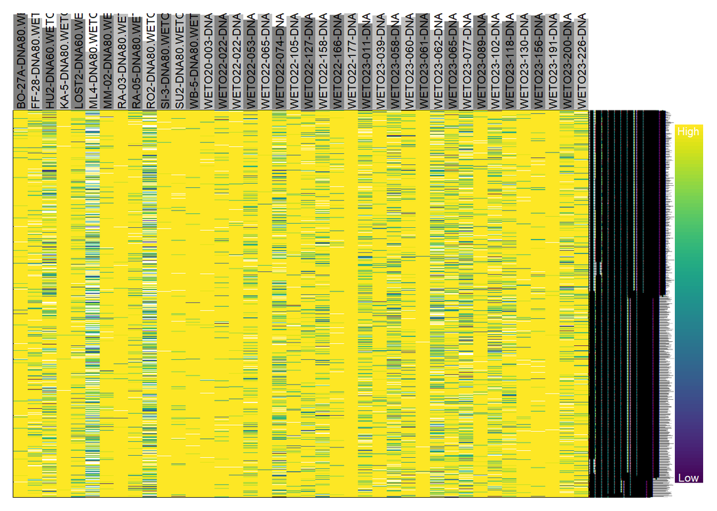

```r
gq <- extract.gt(vcf_mac3_imiss33_SNP95, element= "GQ", as.numeric = TRUE)
heatmap.bp(gq, rlabels=)
```

save the new vcf file:

```r
## Write vcf file that contains only variant sites
#vcfR::write.vcf(vcf_mac3_imiss33_SNP95, "./filtered_vcf/HO_0.5_AB_0.25-0.75_mac3_imiss33_SNP95.vcf.gz")
```

### Conclusions

There is the final data set filtered with less than 33% missing data per individual and less than 5% missing data per SNP.

### Specific notes for the manuscript/thesis

### References

https://devonderaad.github.io/SNPfiltR/ https://devonderaad.github.io/SNPfiltR/reference/index.html

invariant function : https://rpubs.com/juliapereira900/977771